# Getting started with `git`

Amelia Edmondson-Stait & Joseph Crispell

7th Mar, 2025

## Version control

[figure not shown]

*Image taken from [Intro to Reproducible Research in R](https://r-cubed-intro.rostools.org/sessions/version-control)

## What is `git`?

“You use git to take snapshots of all the files in a folder.”

[*Alice Bartlett*](https://speakerdeck.com/alicebartlett/git-for-humans)

[figure not shown]

## Snapshots in time

[figure not shown]

## Snapshots in time

[figure not shown]

## Snapshots in time

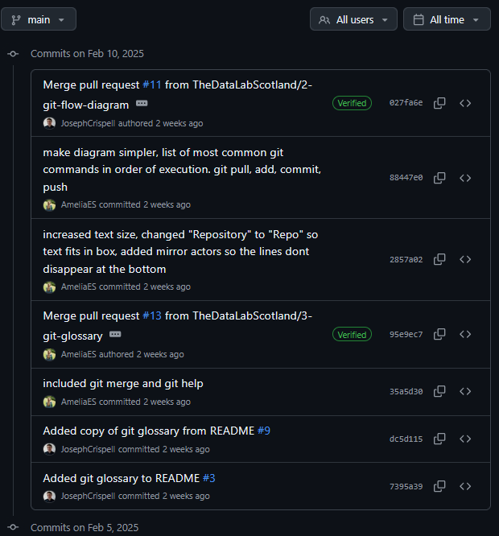

A record of:

- **What** changes were made
- **Who** made them
- **When** they made them

### `git` branch = a working version of your folder

```
%%{init: {
  'theme':'base',
  'gitGraph': {
    'showBranches': true,
    'showCommitLabel':false
  },
  'themeVariables': {
    'tagLabelFontSize': '18px'
  }
}}%%

gitGraph
   commit
   commit

   %% step 1
   branch initial_content
   commit
   commit
   commit
   commit

   %% step 1
   checkout main
   merge initial_content

   branch 3-git-glossary
   checkout 3-git-glossary
   commit
   commit
   commit

   branch 2-git-flow-diagram
   checkout 2-git-flow-diagram
   commit
   commit

   checkout 3-git-glossary
   merge 2-git-flow-diagram

   checkout main
   merge 3-git-glossary
```

## Key concepts

- **Repository** - your project folder
- **Commit** - snapshot of your folder
- **Branch** - working version of your folder
- **Collaboration** - working together on codebase with [GitHub](https://github.com/)/[GitLab](https://about.gitlab.com/)/[Azure DevOps](https://azure.microsoft.com/en-us/products/devops)/…

[figure not shown]

## Key concepts

- **Repository** - your project folder
- **Commit** - snapshot of your folder
  - We `push` snapshots online
  - And `pull` other’s snapshots to local
- **Branch** - working version of your folder
- **Collaboration** - working together on codebase

[figure not shown]

## What is GitHub?

**GitHub** is a cloud-based platform for hosting `git` repositories

Features include:

- [Pull Requests](https://github.blog/developer-skills/github/beginners-guide-to-github-creating-a-pull-request/): Propose changes, review, and discuss before merging branches.
- [Issues and Projects](https://github.com/features/issues): Track bugs, tasks, and enhancements.
- [Actions](https://github.com/features/actions): Automate workflows eg. testing, deployment & CI/CD.
- [Pages](https://pages.github.com/): Host websites directly from repositories.

## Difference between `git` and GitHub

- `git` is a version control system tracking changes to your code locally.
- **GitHub** is a cloud-based platform for hosting `git` repositories.

## `git` commands

[output not shown]

## `git commit` **`--message`**

## `git commit` **`-m`**

- `What is a commit message?`
  - **Text describing changes made in that commit**
- `What should you write in a commit message?`
  - **What** change was made.
  - **Why** the change was necessary.
  - Keep it clear, concise, and meaningful.

## `git commit` **`-m`**

`git commit -m "add slides on writing git commit messages"`

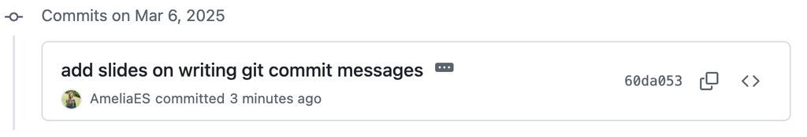

## `git commit` **`-m`**

```
git commit -m "add slides on writing git commit messages" -m "Added slides explaining what a commit message is and how to write one effectively. This helps ensure clear and meaningful commit history for better collaboration."
```

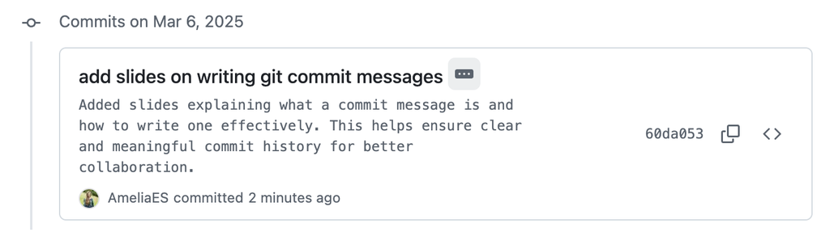

## `git` command glossary

[output not shown]

## `git` pre-commit

Check out [pre-commit](https://pre-commit.com/) hooks as a way to automatically run checks

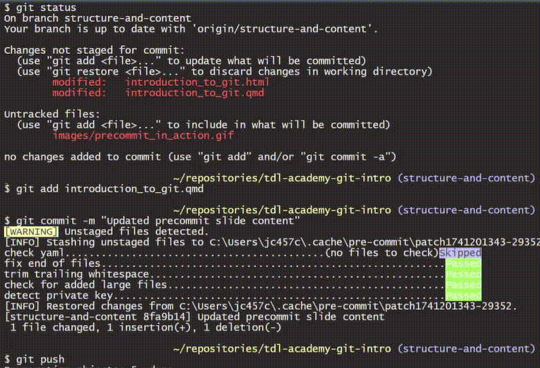

## `git` pre-commit

Check out [pre-commit hooks](https://pre-commit.com/) as a way to automatically run checks

```yaml
repos:
-   repo: https://github.com/pre-commit/pre-commit-hooks
    rev: v4.4.0
    hooks: # info on support hooks here: https://pre-commit.com/hooks.html
    -   id: check-yaml # checks .yaml file formatting
    -   id: end-of-file-fixer # adds empty line at end of file
    -   id: trailing-whitespace # removes extra white space
    -   id: check-added-large-files # doesn't allow files more than 500Kb (configurable)
        args: ['--maxkb=5000']
    -   id: detect-private-key # detects the presence of private keys
```

## Useful resources

- [Introduction to GitHub](https://docs.github.com/en/get-started/start-your-journey/hello-world) and GitHub [documentation](https://docs.github.com/en) pages
- A [game](https://learngitbranching.js.org/) to help us think about git branches
- `git` [command line tutorial](https://git-scm.com/book/en/v2/Getting-Started-The-Command-Line), [handbook](https://guides.github.com/introduction/git-handbook/), and [command glossary](https://github.com/TheDataLabScotland/tdl-academy-git-intro/tree/main?tab=readme-ov-file#git-command-glossary)
- Check out [`git` flow](https://www.alexhyett.com/git-flow-github-flow/) for collaboration
- Version control [guidance](https://best-practice-and-impact.github.io/qa-of-code-guidance/version_control.html) from UK from ONS
- [Writing a Good Git Commit Message](https://www.gitkraken.com/learn/git/best-practices/git-commit-message)

[figure not shown]